# Компьютерная работа

2023-03-18

# Компьютерная работа №1

# Введение

Следующее статистическое исследование направлено на изучение зависимости цены на жилье от нескольких ключевых показателей. Рынок жилья является важнейшим аспектом экономики любого города, поскольку он оказывает влияние как на жителей, так и на бизнес. Таким образом, важно понимать факторы, которые влияют на стоимость жилья. Система показателей включает шесть ключевых переменных, которые, как предполагается, влияют на цены на жилье в этом районе. Первая переменная - это средний доход жителей района, который, как считается, является существенным фактором, определяющим покупательную способность и спрос на жилье. Вторая переменная - это возраст дома, который может указывать на его состояние и соответствие современным стандартам. Третья переменная - это количество комнат в доме, которое может отражать его размер и функциональность. Четвертая переменная - это количество спален в доме, которое может быть существенным фактором при определении его пригодности для проживания семей. Пятая переменная - это население, количество людей, проживающих в данном районе, что может повлиять на спрос на жилье. Наконец, шестая переменная - это цена самого дома, которая является зависимой переменной.

*Гипотеза 1*: Существует положительная корреляция между средним доходом жителей данного района и ценой на жилье. Эта гипотеза предполагает, что более высокий уровень дохода связан с более высокой покупательной способностью, что, в свою очередь, стимулирует спрос на жилье и повышает цены на жилье.

*Гипотеза 2*: Существует положительная корреляция между количеством спален и ценой дома. Эта гипотеза предполагает, что большие дома с большим количеством спален связаны с более высоким спросом и более высокими ценами.

*Гипотеза 3*: Существует отрицательная корреляция между возрастом дома и ценой на него. Эта гипотеза предполагает, что новые дома более желательны и требуют более высоких цен, в то время как старые дома могут иметь устаревшие функции или требовать большего обслуживания, что снижает их стоимость.

Кроме того, размер выборки в 5 000 считается очень большим размером выборки, что повышает вероятность того, что выборка является репрезентативной для населения. Большой размер выборки позволяет более точно оценивать параметры совокупности, такие как среднее значение и дисперсия, что повышает надежность данных.

### Основные характеристики

Читаем данные:

```r
setwd('D:/R')
data <- read.csv("USA_Housing.csv", stringsAsFactors = TRUE)
new_df <- subset(data, select = -c(7))
```

```r
names <- colnames(new_df)
```

Для начала создадим массивы со статистиками с помощью циклов.

```r
SR <- c()
for (i in c(1:6)){
SR <- c(SR, c(mean(new_df[,i])))
}
MO <- c()
for (i in c(1:6)){
MO <- c(MO, c(Mode(new_df[,i])))
}
ME <- c()
for (i in c(1:6)){
ME <- c(ME, c(median(new_df[,i])))
}
RV <- c()
for (i in c(1:6)){
RV <- c(RV, c(diff(range(new_df[,i]))))
}
KV <- c()
for (i in c(1:6)){
KV <- c(KV, c((sd(new_df[,i])/mean(new_df[, i]))*100))
}
DIS <- c()
for (i in c(1:6)){
DIS <- c(DIS, c(var(new_df[,i])))
}
SO <- c()
for (i in c(1:6)){
SO <- c(SO, c(sd(new_df[,i])))
}
```

Теперь занесём значения случайных величин в таблицу для удобного восприятия.

```r
table_data2 <- data.frame(
Переменная = names,
Среднее = SR,
Мода = MO,
Медиана = ME,
Размах_вариации = RV,
Коэффициент_вариации = KV,
Дисперсия = DIS,
Стандартное_отклонение = SO
)
```

Отредактируем вид шрифта и его величину.

```r
my_table <- head(table_data2)
kable(table_data2, format = "html",
      table.attr = 'style="font-family: Arial; font-size: 10px;"')
```

| Переменная | Среднее | Мода | Медиана | Размах_вариации | Коэффициент_вариации | Дисперсия | Стандартное_отклонение |
| --- | --- | --- | --- | --- | --- | --- | --- |
| Avg..Area.Income | 6.858311e+04 | NA | 6.880429e+04 | 8.990512e+04 | 15.54026 | 1.135928e+08 | 1.065799e+04 |
| Avg..Area.House.Age | 5.977222e+00 | NA | 5.970429e+00 | 6.874784e+00 | 16.58724 | 9.829854e-01 | 9.914562e-01 |
| Avg..Area.Number.of.Rooms | 6.987792e+00 | NA | 7.002902e+00 | 7.523394e+00 | 14.39415 | 1.011700e+00 | 1.005833e+00 |
| Avg..Area.Number.of.Bedrooms | 3.981330e+00 | 4.38 | 4.050000e+00 | 4.500000e+00 | 30.99812 | 1.523095e+00 | 1.234137e+00 |
| Area.Population | 3.616352e+04 | NA | 3.619941e+04 | 6.944910e+04 | 27.44658 | 9.851853e+07 | 9.925650e+03 |
| Price | 1.232073e+06 | NA | 1.232669e+06 | 2.453127e+06 | 28.66045 | 1.246921e+11 | 3.531176e+05 |

**Характеристики положения СВ**

**Характеристики разброса**

На основе характеристик разброса случайных величин (СВ) можно сделать следующие выводы:

Выводы показывают, что переменные имеют разный уровень вариабельности, при этом возраст дома имеет относительно низкий диапазон вариации, в то время как количество людей и цена дома имеют высокие диапазоны вариации и исходя из значени1 коэффициентов вариации можно сделать вывод о том, что все данные однородные.

### Ранговые характеристики

Теперь перейдём к ранговым характеристикам. Для начала подсчитаем квартильные группы:

```r
pander(quantile(new_df$Avg..Area.Income))
```

| 0% | 25% | 50% | 75% | 100% |
| --- | --- | --- | --- | --- |
| 17797 | 61481 | 68804 | 75783 | 107702 |

```r
pander(quantile(new_df$Avg..Area.House.Age))
```

| 0% | 25% | 50% | 75% | 100% |
| --- | --- | --- | --- | --- |
| 2.644 | 5.322 | 5.97 | 6.651 | 9.519 |

```r
pander(quantile(new_df$Avg..Area.Number.of.Rooms))
```

| 0% | 25% | 50% | 75% | 100% |
| --- | --- | --- | --- | --- |
| 3.236 | 6.299 | 7.003 | 7.666 | 10.76 |

```r
pander(quantile(new_df$Avg..Area.Number.of.Bedrooms))
```

| 0% | 25% | 50% | 75% | 100% |
| --- | --- | --- | --- | --- |
| 2 | 3.14 | 4.05 | 4.49 | 6.5 |

```r
pander(quantile(new_df$Area.Population))
```

| 0% | 25% | 50% | 75% | 100% |
| --- | --- | --- | --- | --- |
| 172.6 | 29404 | 36199 | 42861 | 69622 |

```r
pander(quantile(new_df$Avg..Area.Income))
```

| 0% | 25% | 50% | 75% | 100% |
| --- | --- | --- | --- | --- |
| 17797 | 61481 | 68804 | 75783 | 107702 |

```r
pander(quantile(new_df$Price))
```

| 0% | 25% | 50% | 75% | 100% |
| --- | --- | --- | --- | --- |
| 15939 | 997577 | 1232669 | 1471210 | 2469066 |

А сейчас посчитаем децильные группы:

```r
pander(quantile(new_df$Avg..Area.Income, probs = seq(0, 1, 0.1)))
```

| 0% | 10% | 20% | 30% | 40% | 50% | 60% | 70% | 80% | 90% | 100% |
| --- | --- | --- | --- | --- | --- | --- | --- | --- | --- | --- |
| 17797 | 55048 | 59765 | 62931 | 65986 | 68804 | 71341 | 74232 | 77413 | 82081 | 107702 |

```r
pander(quantile(new_df$Avg..Area.House.Age, probs = seq(0, 1, 0.1)))
```

| 0% | 10% | 20% | 30% | 40% | 50% | 60% | 70% | 80% | 90% | 100% |
| --- | --- | --- | --- | --- | --- | --- | --- | --- | --- | --- |
| 2.644 | 4.698 | 5.154 | 5.46 | 5.707 | 5.97 | 6.245 | 6.497 | 6.81 | 7.244 | 9.519 |

```r
pander(quantile(new_df$Avg..Area.Number.of.Rooms, probs = seq(0, 1, 0.1)))
```

| 0% | 10% | 20% | 30% | 40% | 50% | 60% | 70% | 80% | 90% | 100% |
| --- | --- | --- | --- | --- | --- | --- | --- | --- | --- | --- |
| 3.236 | 5.682 | 6.132 | 6.463 | 6.744 | 7.003 | 7.259 | 7.519 | 7.842 | 8.274 | 10.76 |

```r
pander(quantile(new_df$Avg..Area.Number.of.Bedrooms, probs = seq(0, 1, 0.1)))
```

| 0% | 10% | 20% | 30% | 40% | 50% | 60% | 70% | 80% | 90% | 100% |
| --- | --- | --- | --- | --- | --- | --- | --- | --- | --- | --- |
| 2 | 2.31 | 3.06 | 3.22 | 3.39 | 4.05 | 4.22 | 4.4 | 5.17 | 6.1 | 6.5 |

```r
pander(quantile(new_df$Area.Population, probs = seq(0, 1, 0.1)))
```

| 0% | 10% | 20% | 30% | 40% | 50% | 60% | 70% | 80% | 90% | 100% |
| --- | --- | --- | --- | --- | --- | --- | --- | --- | --- | --- |
| 172.6 | 23503 | 27720 | 30995 | 33579 | 36199 | 38734 | 41380 | 44382 | 48814 | 69622 |

```r
pander(quantile(new_df$Price, probs = seq(0, 1, 0.1)))
```

Table continues below

| 0% | 10% | 20% | 30% | 40% | 50% | 60% | 70% |
| --- | --- | --- | --- | --- | --- | --- | --- |
| 15939 | 772032 | 938063 | 1048002 | 1139514 | 1232669 | 1323069 | 1418396 |

| 80% | 90% | 100% |
| --- | --- | --- |
| 1532652 | 1684621 | 2469066 |

## 3. Диагностика выбросов.

Для начала построим ящичковую диаграмму и проверим предположение и наличии выбросов слева

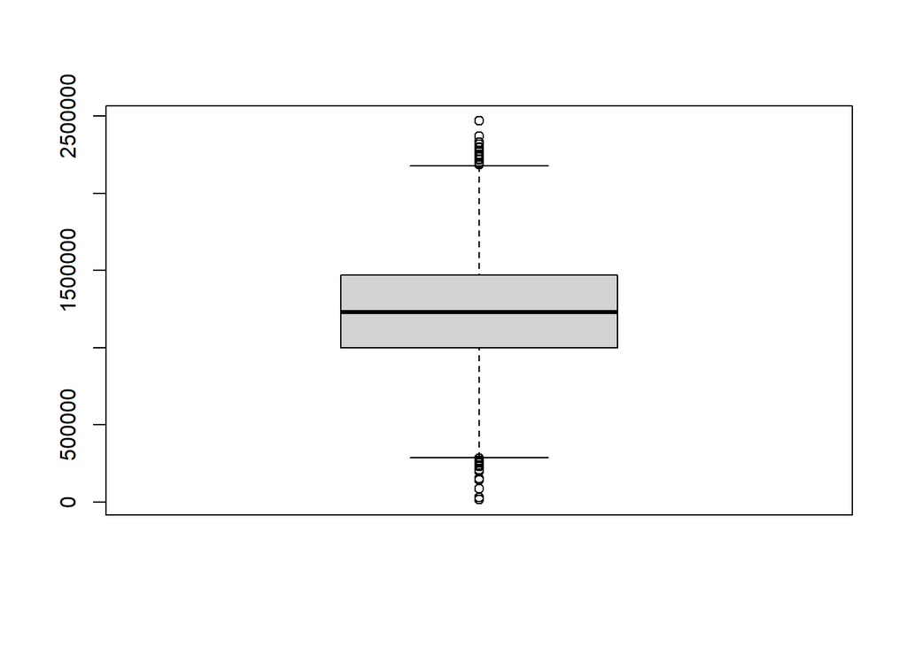

```r
boxplot(new_df$Price)
```

Исходя из диаграммы мы можем сказать, что имеются выбросы и слева и справа

### Найдем IQR

```r
IQR(new_df$Price)
```

```
## [1] 473633.1
```

Проверим наличие выбросов по правилу 1,5 IQR

```r
Price_sorted <- sort(new_df$Price)
out_of_1.5IQR <- boxplot.stats(new_df$Price)$out
out_of_1.5IQR
```

```
##  [1]  201898.09 2298379.49  152071.87 2249122.54 2469065.59 2252243.34
##  [7] 2332110.74  283208.13 2237778.03 2271112.74 2330289.70 2185480.09
## [13] 2198564.57 2318285.70   31140.52  239319.93  143027.36 2186194.79
## [19] 2220799.07 2235294.72  211017.97  151527.08   88591.77 2275455.31
## [25] 2294647.78 2370231.32  231189.82 2197436.88  268050.81   15938.66
## [31] 2190338.61  266298.88 2187326.44 2219724.16  253185.70
```

```r
out_of_1.5IQR_ind <- which(Price_sorted %in% out_of_1.5IQR)
out_of_1.5IQR_ind
```

```
##  [1]    1    2    3    4    5    6    7    8    9   10   11   12   13   14 4980
## [16] 4981 4982 4983 4984 4985 4986 4987 4988 4989 4990 4991 4992 4993 4994 4995
## [31] 4996 4997 4998 4999 5000
```

Мы получили выбросы по правилу 1,5 IQR

Теперь сделаем дигностику выбросов по правилу 3 IQR

```r
Price_sorted <- sort(new_df$Price)
out_of_3IQR <- boxplot.stats(new_df$Price, coef=3)$out
out_of_3IQR
```

```
## numeric(0)
```

Выбросов по правилу 3 IQR нет.

Правило 3-х сигм:

```r
m1 <- mean(new_df$Price) - 3*sd(new_df$Price)
m2 <- mean(new_df$Price) + 3*sd(new_df$Price)

new_df1 <- new_df[order(new_df$Price, decreasing = FALSE), ]
```

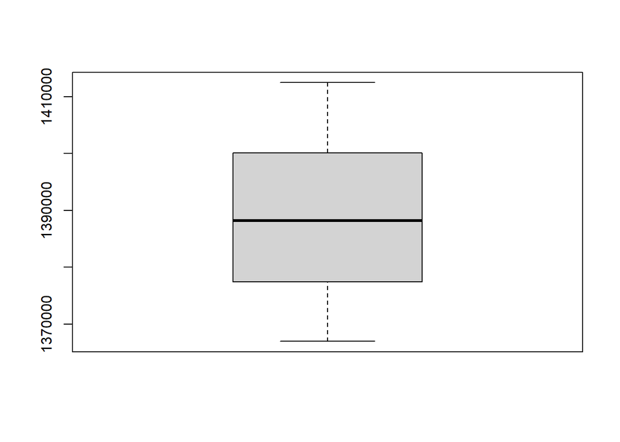

```r
new_df3 <- new_df1[max(which(new_df$Price <= m1))+1:min(which(new_df$Price >= m2))-1, ]
boxplot(new_df3$Price)
```

##### Проверим наличие аномальных наблюдений с помощью критерия Граббса:

Поскольку не было найдено выбросов по правилу 3 IQR, проверим наличие выбросов по исходным данным

```r
grubbs.test(new_df$Price)
```

```
##
##  Grubbs test for one outlier
##
## data:  new_df$Price
## G = 3.50306, U = 0.99754, p-value = 1
## alternative hypothesis: highest value 2469065.5941747 is an outlier
```

p-value = 1. Значит гипотеза об отсутсвии аномальных наблюдений не отвергается

Проверим наши данные с помощью теста Рознера

```r
rosnerTest(new_df$Price)
```

```
## $distribution
## [1] "Normal"
##
## $statistic
##      R.1      R.2      R.3
## 3.503062 3.447181 3.408486
##
## $sample.size
## [1] 5000
##
## $parameters
## k
## 3
##
## $alpha
```

[output cut: 865 more lines]

Аналогично критерию Граббса по тесту Рознера не выявлено аномальных наблюдений, значит для исследования используем исходные данные (`new_df`)

##Проверка соответствия эмпирического распределения нормальному закону

```r
AS <- c()
for (i in c(1:6)){
AS <- c(AS, c(skewness(new_df[,i], na.rm = TRUE)))
}
ES <- c()
for (i in c(1:6)){
ES <- c(ES, c(kurtosis(new_df[,i], na.rm = TRUE)))
}
```

```r
table_data3 <- data.frame(Переменная = names, Коэффициент_ассиметрии = AS, Коэффициент_эксцесса = ES)
```

```r
my_table1 <- head(table_data3)
kable(table_data3, format = "html",
table.attr = 'style="font-family: Arial; font-size: 10px;"')
```

| Переменная | Коэффициент_ассиметрии | Коэффициент_эксцесса |
| --- | --- | --- |
| Avg..Area.Income | -0.0337200 | 0.0455738 |
| Avg..Area.House.Age | -0.0072139 | -0.0834373 |
| Avg..Area.Number.of.Rooms | -0.0409959 | -0.0746522 |
| Avg..Area.Number.of.Bedrooms | 0.3762404 | -0.7015656 |
| Area.Population | 0.0506497 | -0.0067329 |
| Price | -0.0027181 | -0.0549181 |

### Построение гистограммы распределения

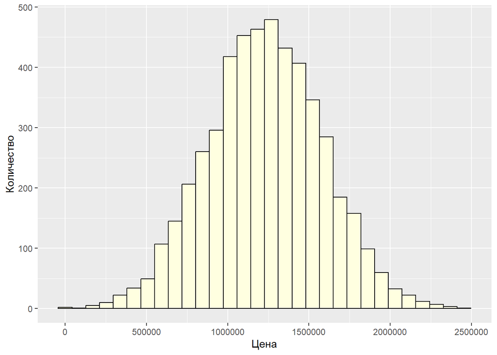

```r
ggplot(new_df, aes(x = new_df$Price)) +
  geom_histogram(color = "black", fill = "lightyellow") +
  ylab("Количество") +
  xlab("Цена")
```

*Как мы можем заметить наша гистограмма напоминает нам нормальное распределение, попробуем наложить плотность распределения.*

Гистограмма распределения переменной с наложением плотности нормального распределения:

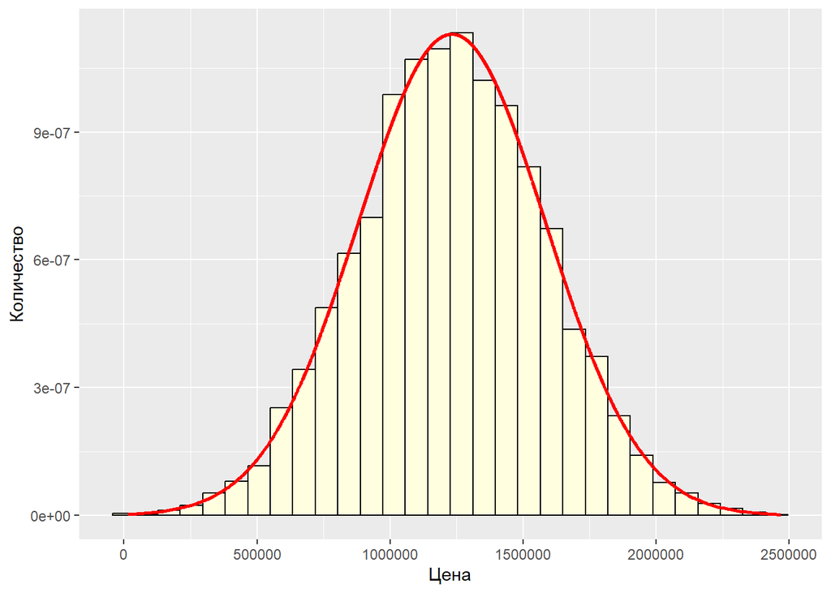

```r
ggplot(new_df, aes(x = new_df$Price)) +
  geom_histogram(aes(y=..density..), color = "black", fill = "lightyellow") +
  geom_line(aes(x = new_df$Price, y = dnorm(new_df$Price, mean = mean(new_df$Price), sd = sd(new_df$Price))), lwd = 1, col = 'red') +
  ylab("Количество") +
  xlab("Цена")
```

*Как мы можем заметить, плотность нормального распределения очень хорошо накладывается на гистограмму распределения, далее стоит проверить гипотезу о том, что выборка взята из генеральной совокупности с нормальным распределением.*

### 3. Проверка гипотезы о распределении генеральной совокупности

$$H_0 : \text{ выборка взята из генеральной совокупности с нормальным
распределением }$$

Китерий Пирсона

```r
pander(PearsonTest(new_df$Price))
```

Pearson chi-square normality test: `new_df$Price`

| Test statistic | P value |
| --- | --- |
| 60.02 | 0.4023 |

*Нулевая гипотеза не может быть отвергнута на уровне значимости 5%.*

Критерий Колмогорова

```r
pander(ks.test(new_df$Price, 'pnorm', mean(new_df$Price), sd(new_df$Price)))
```

Asymptotic one-sample Kolmogorov-Smirnov test: `new_df$Price` *P-value больше выбранного уровня значимости 5%, значит, нулевая гипотеза о нормальности распределения не отвергается.*

| Test statistic | P value | Alternative hypothesis |
| --- | --- | --- |
| 0.007577 | 0.9364 | two-sided |

```r
pander(shapiro.test(new_df$Price))
```

Shapiro-Wilk normality test: `new_df$Price`

| Test statistic | P value |
| --- | --- |
| 0.9998 | 0.9495 |

*P-value больше выбранного уровня значимости 5%, значит, нулевая гипотеза о нормальности распределения не отвергается.*

### Построение dotplot по всем переменным

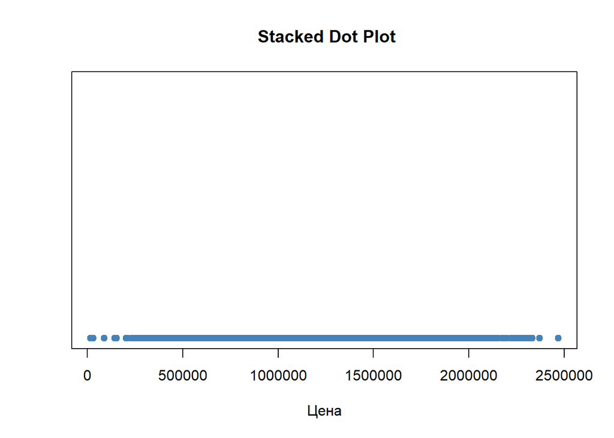

```r
stripchart(new_df$Price, method = "stack", offset = .5 , at = 0 , pch = 19 ,
 col = " steelblue", main = " Stacked Dot Plot", xlab = " Цена ")
```

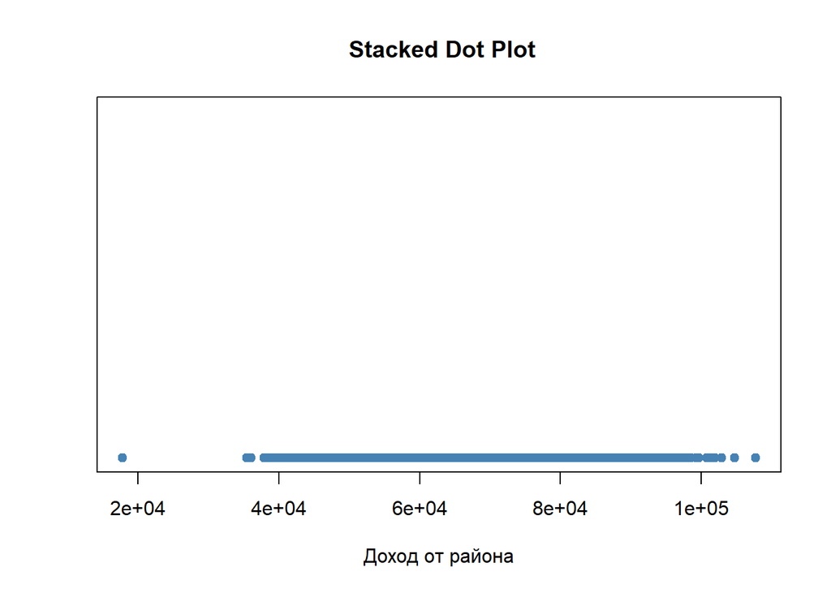

```r
stripchart(new_df$Avg..Area.Income, method = "stack", offset = .5 , at = 0 , pch = 19 ,
 col = " steelblue", main = " Stacked Dot Plot", xlab = " Доход от района ")
```

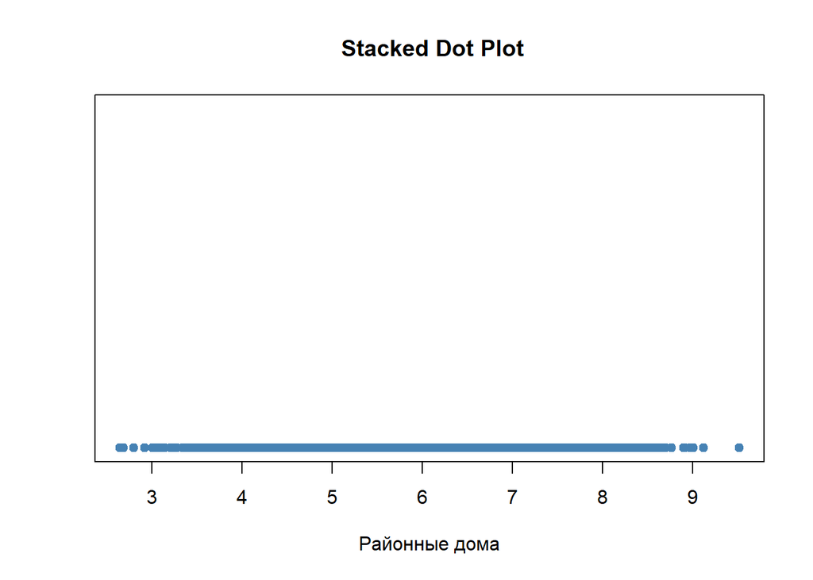

```r
stripchart(new_df$Avg..Area.House, method = "stack", offset = .5 , at = 0 , pch = 19 ,
 col = " steelblue", main = " Stacked Dot Plot", xlab = " Районные дома ")
```

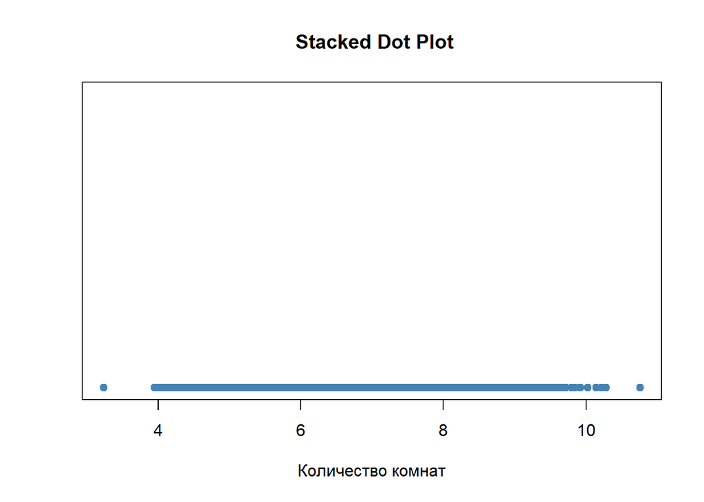

```r
stripchart(new_df$Avg..Area.Number.of.Rooms, method = "stack", offset = .5 , at = 0 , pch = 19 ,
 col = " steelblue", main = " Stacked Dot Plot", xlab = " Количество комнат ")
```

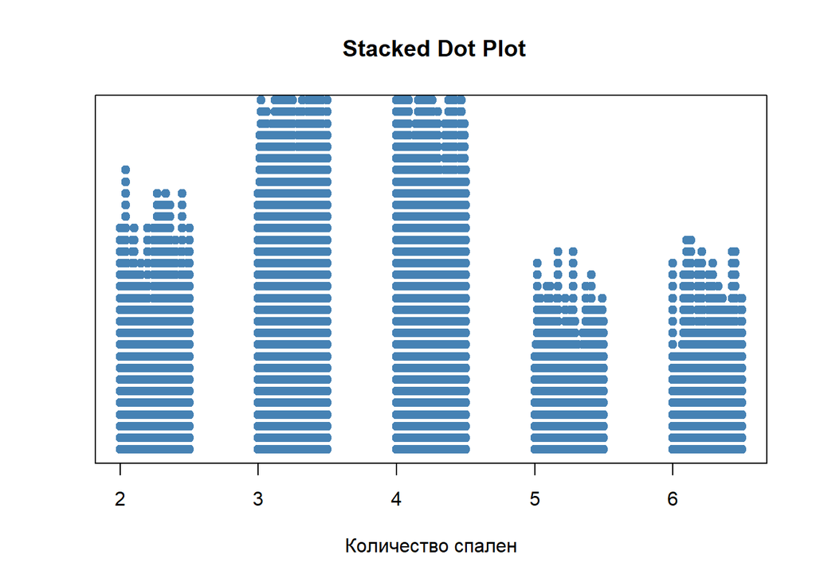

```r
stripchart(new_df$Avg..Area.Number.of.Bedrooms, method = "stack", offset = .5 , at = 0 , pch = 19 ,
 col = " steelblue", main = " Stacked Dot Plot", xlab = " Количество спален ")
```

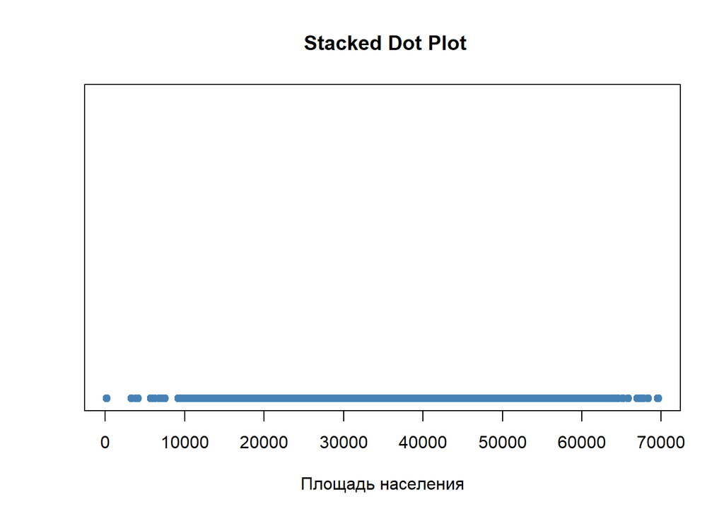

```r
stripchart(new_df$Area.Population, method = "stack", offset = .5 , at = 0 , pch = 19 ,
 col = " steelblue", main = " Stacked Dot Plot", xlab = " Площадь населения ")
```

*Как мы можем заметить, что для некоторых признаков график не интерпретабелен, поскольку значения распределены равномерно и нет повторяющихся. Но, например, для графика по признаку “количество спален” мы можем заметить, что большую часть в векторе занимают значения 3 и 4, что говорит о том, что люди чаще всего предпочитают такое спален у себя дома.*

# Корреляционный анализ

В данном пункте мы будем пытаться найти корреляционные зависимости между переменными, в основном все переменные так или иначе будут связаны с ценой, потому что именно ее зависимость от остальных переменных мы хотим изучить.

#### Построим облако корреляции

Для выполнения данного пункта задания я рассмотрю несколько случаев зависимости между переменными, в каких то случаях она будет отрицательной прямой, в каких-то положительная прямая, а в каких-то зависимость будет полностью отсутствовать.

Для начала построим несколько отдельных графиков, потом построим общие таблицы с графиками для всех переменных.

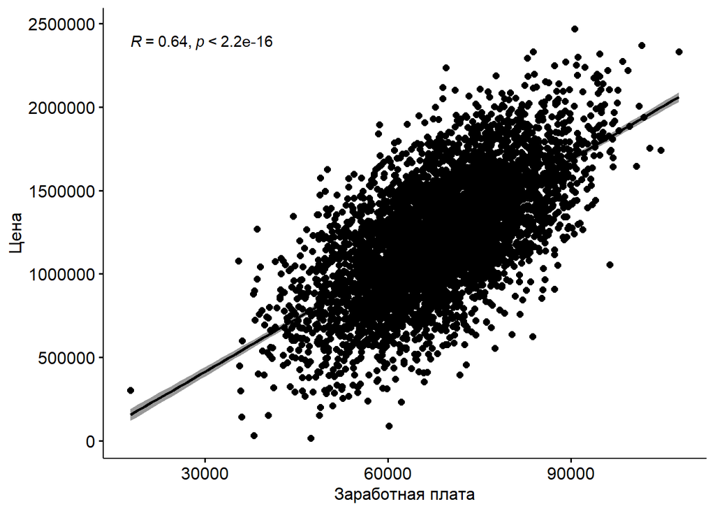

```r
ggscatter(new_df, x = "Avg..Area.Income", y = "Price",
          add = "reg.line", conf.int = TRUE,
          cor.coef = TRUE, cor.method = "pearson",
          xlab = "Заработная плата", ylab = "Цена")
```

Как мы видим на данном графике, зависимость достаточно сильная, коэффициент корреляции равен 0,64, что говорит об умеренной положительной зависимости, коэффициент значимый, так как значение p_value, меньше заданного уровня значимости 0,05

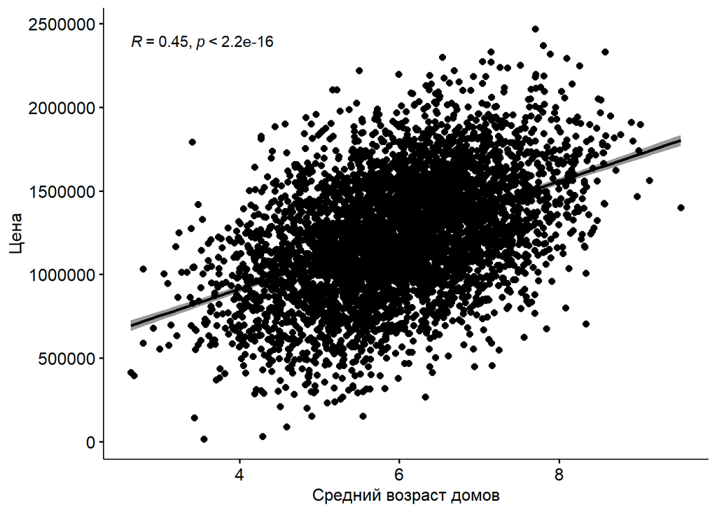

```r
ggscatter(new_df, x = "Avg..Area.House.Age", y = "Price",
          add = "reg.line", conf.int = TRUE,
          cor.coef = TRUE, cor.method = "pearson",
          xlab = "Средний возраст домов", ylab = "Цена")
```

На графике видна умеренная зависимость (0,45) между переменными средний возраст домов и ценой на них, коэффициент значимый.

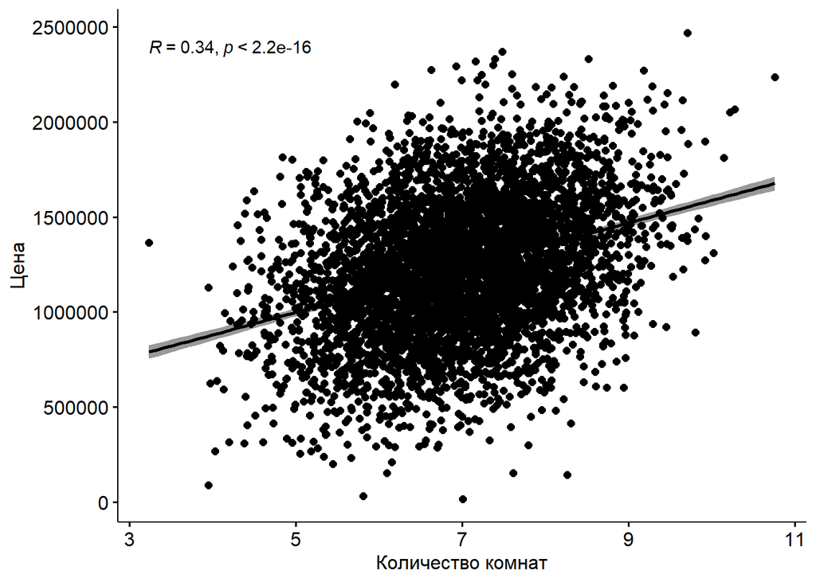

```r
ggscatter(new_df, x = "Avg..Area.Number.of.Rooms", y = "Price",
          add = "reg.line", conf.int = TRUE,
          cor.coef = TRUE, cor.method = "pearson",
          xlab = "Количество комнат", ylab = "Цена")
```

На графике видна умеренная зависимость (0,34) между переменными количеством комнат и ценой, коэффициент значимый.

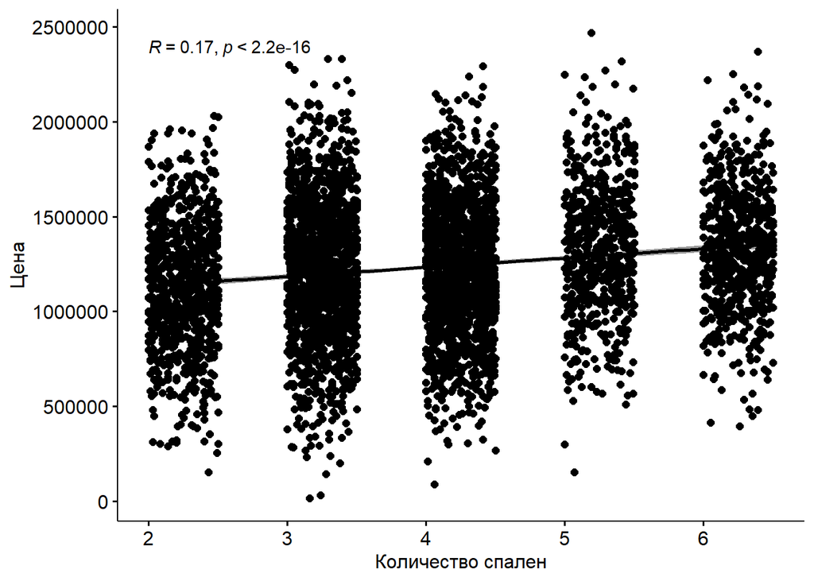

```r
ggscatter(new_df, x = "Avg..Area.Number.of.Bedrooms", y = "Price",
          add = "reg.line", conf.int = TRUE,
          cor.coef = TRUE, cor.method = "pearson",
          xlab = "Количество спален", ylab = "Цена")
```

На данном графике видно, что цена конечно зависит от количества спален, но на общей картине этого не видно, потому что разделения по количеству спален очень резкие. Связь слабая (0,17)

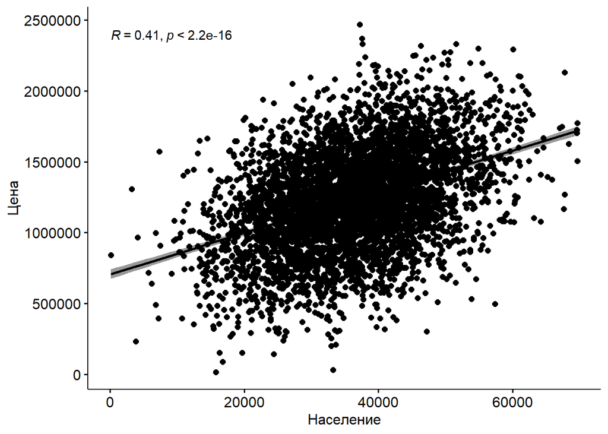

```r
ggscatter(new_df, x = "Area.Population", y = "Price",
          add = "reg.line", conf.int = TRUE,
          cor.coef = TRUE, cor.method = "pearson",
          xlab = "Население", ylab = "Цена")
```

На графике видна умеренная зависимость (0,41) между переменными количеством населения и ценой, коэффициент значимый.

#### Теперь приведем несколько графиков, на которых видна сильная положительная зависимость, отрицательная и отсутствие зависимости.

Самая сильная зависимость у нас была между переменными Price и Avg..Area.Income, я анализировал эти графики ранне, поэтому не буду приводить их здесь опять

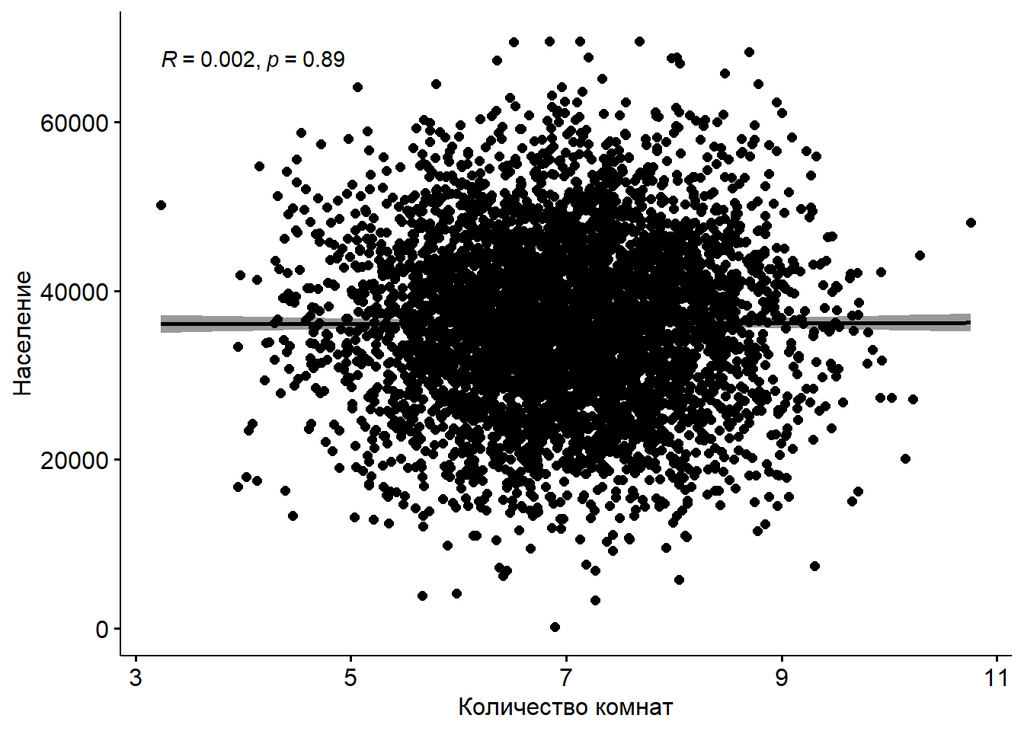

```r
ggscatter(new_df, x = "Avg..Area.Number.of.Rooms", y = "Area.Population",
          add = "reg.line", conf.int = TRUE,
          cor.coef = TRUE, cor.method = "pearson",
          xlab = "Количество комнат", ylab = "Население")
```

На данном графике полностью отсуствует зависимость, коэффициент корреляции очень маленький и не значимый, потому что значение p_value больше заданного уровня значимости 0,05

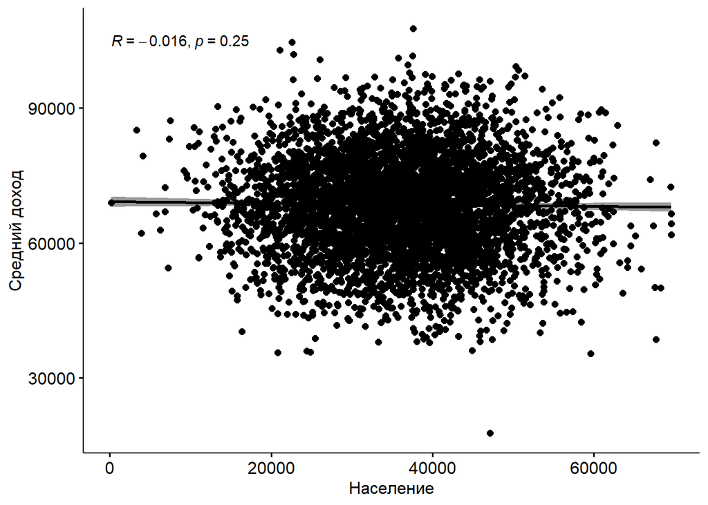

```r
ggscatter(new_df, x = "Area.Population", y = "Avg..Area.Income",
          add = "reg.line", conf.int = TRUE,
          cor.coef = TRUE, cor.method = "pearson",
          xlab = "Население", ylab = "Средний доход")
```

На данном графике видна слабая отрицательная зависимость между переменными, коэффициент незначим

#### Теперь выведем общие графики для всех переменных

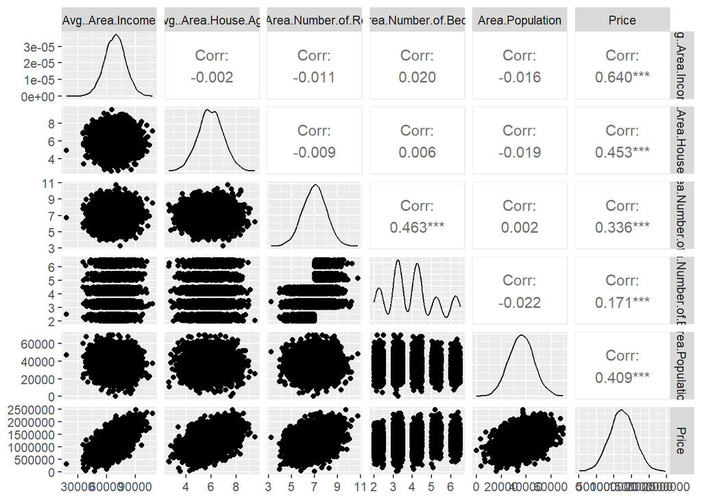

```r
ggpairs(new_df[1:6])
```

### Построение корреляционной матрицы, парных коэффициентов корреляции.

```r
cor(new_df, method = "pearson")
```

```
##                              Avg..Area.Income Avg..Area.House.Age
## Avg..Area.Income                  1.000000000        -0.002006826
## Avg..Area.House.Age              -0.002006826         1.000000000
## Avg..Area.Number.of.Rooms        -0.011031660        -0.009428292
## Avg..Area.Number.of.Bedrooms      0.019788221         0.006148923
## Area.Population                  -0.016233740        -0.018742762
## Price                             0.639733778         0.452542537
##                              Avg..Area.Number.of.Rooms
## Avg..Area.Income                          -0.011031660
## Avg..Area.House.Age                       -0.009428292
## Avg..Area.Number.of.Rooms                  1.000000000
## Avg..Area.Number.of.Bedrooms               0.462694860
## Area.Population                            0.002039928
## Price                                      0.335664453
##                              Avg..Area.Number.of.Bedrooms Area.Population
## Avg..Area.Income                              0.019788221    -0.016233740
## Avg..Area.House.Age                           0.006148923    -0.018742762
## Avg..Area.Number.of.Rooms                     0.462694860     0.002039928
## Avg..Area.Number.of.Bedrooms                  1.000000000    -0.022167642
## Area.Population                              -0.022167642     1.000000000
## Price                                         0.171071028     0.408555879
##                                  Price
## Avg..Area.Income             0.6397338
## Avg..Area.House.Age          0.4525425
## Avg..Area.Number.of.Rooms    0.3356645
## Avg..Area.Number.of.Bedrooms 0.1710710
## Area.Population              0.4085559
## Price                        1.0000000
```

Так как мы хотим сравнить зависимости между переменной Price и остальными переменными, следовательно будем брать во внимание только последнюю строчку.

Как мы видим, самая сильная прямая зависимость у нас существует между переменной Price и Avg..Area.Income, с другими переменными связь есть, но умеренная, только между переменной Avg..Area.Number.of.Bedrooms связь слабая.

Так же есть интересная средняя зависимость между Avg..Area.Number.of.Bedrooms и Avg..Area.Number.of.Rooms.

Для примера я вынес один отдельный парный коеффициент корреляции между переменными Price и Avg..Area.Income, на котором видно, что данный коэффициент значимый и его доверительный интервал равен 0.6230632 < p < 0.6558234

```r
cor.test(new_df$Price, new_df$Avg..Area.Income, method = "pearson")
```

```
##
##  Pearson's product-moment correlation
##
## data:  new_df$Price and new_df$Avg..Area.Income
## t = 58.844, df = 4998, p-value < 2.2e-16
## alternative hypothesis: true correlation is not equal to 0
## 95 percent confidence interval:
##  0.6230632 0.6558234
## sample estimates:
##       cor
## 0.6397338
```

```r
cor <- cor(new_df, method = "pearson")
```

Теперь нужно визуализировать данную матрицу

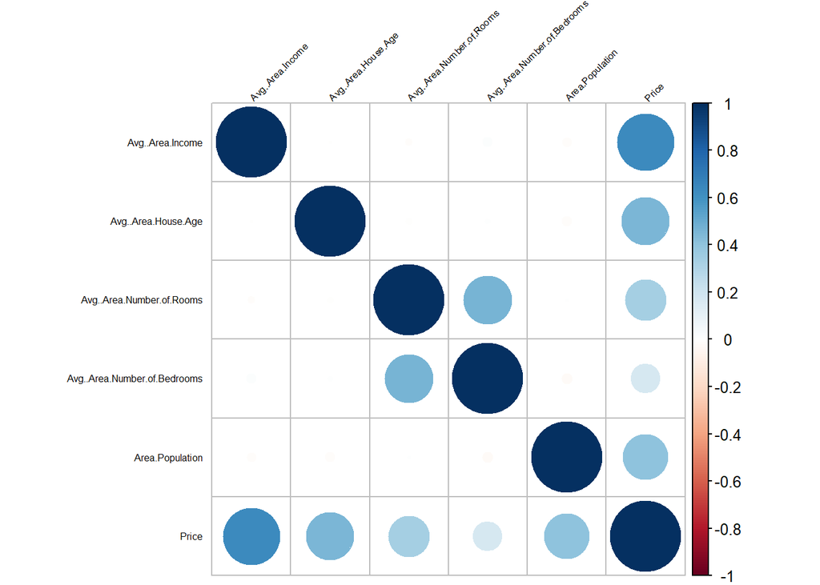

```r
corrplot(as.matrix(cor), type = "full", method = "circle", tl.col = "black", tl.srt = 45, tl.cex = 0.5)
```

На данном графике мы видим все те же результаты, что и с помощью невизуализированной матрицы.

Комбинируем оценку корреляционной матрицы с результатами тестов на значимость:

Матрица

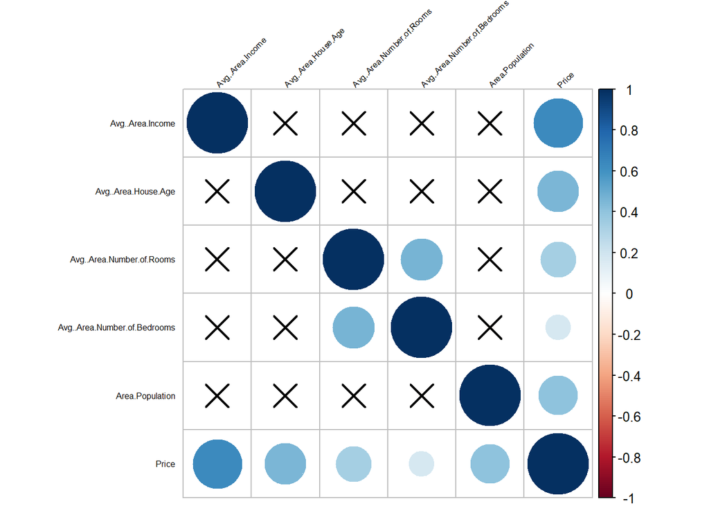

```r
res <- cor.mtest(new_df, conf.level = 0.95)
corrplot(cor(new_df), p.mat = res$p, sig.level = 0.05, tl.col = "black", tl.srt = 45, tl.cex = 0.5)
```

Как мы видим, некотторые коэффициенты незначимые

Теперь я буду искать доверительные интервалы для значимых коэффициентов корреляции

```r
cor.test(new_df$Area.Population, new_df$Avg..Area.Income, method = "pearson")
```

```
##
##  Pearson's product-moment correlation
##
## data:  new_df$Area.Population and new_df$Avg..Area.Income
## t = -1.1478, df = 4998, p-value = 0.2511
## alternative hypothesis: true correlation is not equal to 0
## 95 percent confidence interval:
##  -0.04393326  0.01149072
## sample estimates:
##         cor
## -0.01623374
```

В данном случае значение 0 попало в доверительный интервал, следовательно коэффициент статистически незначимый

```r
cor.test(new_df$Area.Population, new_df$Avg..Area.House.Age, method = "pearson")
```

```
##
##  Pearson's product-moment correlation
##
## data:  new_df$Area.Population and new_df$Avg..Area.House.Age
## t = -1.3253, df = 4998, p-value = 0.1851
## alternative hypothesis: true correlation is not equal to 0
## 95 percent confidence interval:
##  -0.046437929  0.008981197
## sample estimates:
##         cor
## -0.01874276
```

В данном случае значение 0 попало в доверительный интервал, следовательно коэффициент статистически незначимый

```r
cor.test(new_df$Avg..Area.Number.of.Bedrooms, new_df$Avg..Area.Number.of.Rooms, method = "pearson")
```

```
##
##  Pearson's product-moment correlation
##
## data:  new_df$Avg..Area.Number.of.Bedrooms and new_df$Avg..Area.Number.of.Rooms
## t = 36.898, df = 4998, p-value < 2.2e-16
## alternative hypothesis: true correlation is not equal to 0
## 95 percent confidence interval:
##  0.4406269 0.4842040
## sample estimates:
##       cor
## 0.4626949
```

В данном случае значение 0 не попало в доверительный интервал, следовательно коэффициент статистически значимый

```r
cor.test(new_df$Price, new_df$Avg..Area.Income, method = "pearson")
```

```
##
##  Pearson's product-moment correlation
##
## data:  new_df$Price and new_df$Avg..Area.Income
## t = 58.844, df = 4998, p-value < 2.2e-16
## alternative hypothesis: true correlation is not equal to 0
## 95 percent confidence interval:
##  0.6230632 0.6558234
## sample estimates:
##       cor
## 0.6397338
```

В данном случае значение 0 не попало в доверительный интервал, следовательно коэффициент статистически значимый

```r
cor.test(new_df$Price, new_df$Avg..Area.House.Age, method = "pearson")
```

```
##
##  Pearson's product-moment correlation
##
## data:  new_df$Price and new_df$Avg..Area.House.Age
## t = 35.877, df = 4998, p-value < 2.2e-16
## alternative hypothesis: true correlation is not equal to 0
## 95 percent confidence interval:
##  0.430220 0.474312
## sample estimates:
##       cor
## 0.4525425
```

В данном случае значение 0 не попало в доверительный интервал, следовательно коэффициент статистически значимый

```r
cor.test(new_df$Price, new_df$Avg..Area.Number.of.Rooms, method = "pearson")
```

```
##
##  Pearson's product-moment correlation
##
## data:  new_df$Price and new_df$Avg..Area.Number.of.Rooms
## t = 25.192, df = 4998, p-value < 2.2e-16
## alternative hypothesis: true correlation is not equal to 0
## 95 percent confidence interval:
##  0.3108373 0.3600339
## sample estimates:
##       cor
## 0.3356645
```

В данном случае значение 0 не попало в доверительный интервал, следовательно коэффициент статистически значимый

```r
cor.test(new_df$Price, new_df$Avg..Area.Number.of.Bedrooms, method = "pearson")
```

```
##
##  Pearson's product-moment correlation
##
## data:  new_df$Price and new_df$Avg..Area.Number.of.Bedrooms
## t = 12.275, df = 4998, p-value < 2.2e-16
## alternative hypothesis: true correlation is not equal to 0
## 95 percent confidence interval:
##  0.1440347 0.1978521
## sample estimates:
##      cor
## 0.171071
```

В данном случае значение 0 не попало в доверительный интервал, следовательно коэффициент статистически значимый

```r
cor.test(new_df$Price, new_df$Area.Population, method = "pearson")
```

```
##
##  Pearson's product-moment correlation
##
## data:  new_df$Price and new_df$Area.Population
## t = 31.645, df = 4998, p-value < 2.2e-16
## alternative hypothesis: true correlation is not equal to 0
## 95 percent confidence interval:
##  0.3851989 0.4313897
## sample estimates:
##       cor
## 0.4085559
```

В данном случае значение 0 не попало в доверительный интервал, следовательно коэффициент статистически значимый

## Построим матрицу частных коэффициентов корреляции

```r
cor_p <- pcor(scale(new_df))
colnames(cor_p$estimate) <- names(new_df)
rownames(cor_p$estimate) <- names(new_df)
cor_p$estimate
```

```
##                              Avg..Area.Income Avg..Area.House.Age
## Avg..Area.Income                  1.000000000         -0.77999556
## Avg..Area.House.Age              -0.779995557          1.00000000
## Avg..Area.Number.of.Rooms        -0.673149904         -0.62528718
## Avg..Area.Number.of.Bedrooms     -0.005188391         -0.00919868
## Area.Population                  -0.763752221         -0.71261345
## Price                             0.915357932          0.85149082
##                              Avg..Area.Number.of.Rooms
## Avg..Area.Income                            -0.6731499
## Avg..Area.House.Age                         -0.6252872
## Avg..Area.Number.of.Rooms                    1.0000000
## Avg..Area.Number.of.Bedrooms                 0.3042597
## Area.Population                             -0.6000819
## Price                                        0.7285870
##                              Avg..Area.Number.of.Bedrooms Area.Population
## Avg..Area.Income                             -0.005188391     -0.76375222
## Avg..Area.House.Age                          -0.009198680     -0.71261345
## Avg..Area.Number.of.Rooms                     0.304259667     -0.60008188
## Avg..Area.Number.of.Bedrooms                  1.000000000     -0.02897586
## Area.Population                              -0.028975858      1.00000000
## Price                                         0.017850880      0.83056879
##                                   Price
## Avg..Area.Income             0.91535793
## Avg..Area.House.Age          0.85149082
## Avg..Area.Number.of.Rooms    0.72858696
## Avg..Area.Number.of.Bedrooms 0.01785088
## Area.Population              0.83056879
## Price                        1.00000000
```

Нас интересует перменная Price, у нас присутствует сильная положительная зависимость между всеми переменными за исключением Avg..Area.Number.of.Bedrooms.

Проверим значимость

```r
cor_p$p.value
```

```
##                              Avg..Area.Income Avg..Area.House.Age
## Avg..Area.Income                    0.0000000           0.0000000
## Avg..Area.House.Age                 0.0000000           0.0000000
## Avg..Area.Number.of.Rooms           0.0000000           0.0000000
## Avg..Area.Number.of.Bedrooms        0.7138886           0.5156691
## Area.Population                     0.0000000           0.0000000
## Price                               0.0000000           0.0000000
##                              Avg..Area.Number.of.Rooms
## Avg..Area.Income                          0.000000e+00
## Avg..Area.House.Age                       0.000000e+00
## Avg..Area.Number.of.Rooms                 0.000000e+00
## Avg..Area.Number.of.Bedrooms             1.672169e-107
## Area.Population                           0.000000e+00
## Price                                     0.000000e+00
##                              Avg..Area.Number.of.Bedrooms Area.Population
## Avg..Area.Income                             7.138886e-01      0.00000000
## Avg..Area.House.Age                          5.156691e-01      0.00000000
## Avg..Area.Number.of.Rooms                   1.672169e-107      0.00000000
## Avg..Area.Number.of.Bedrooms                 0.000000e+00      0.04055996
## Area.Population                              4.055996e-02      0.00000000
## Price                                        2.071188e-01      0.00000000
##                                  Price
## Avg..Area.Income             0.0000000
## Avg..Area.House.Age          0.0000000
## Avg..Area.Number.of.Rooms    0.0000000
## Avg..Area.Number.of.Bedrooms 0.2071188
## Area.Population              0.0000000
## Price                        0.0000000
```

Все коэффициенты связанные с Price значимые, кроме Avg..Area.Number.of.Bedrooms, незначимыми так же являются коэффициенты между переменными Avg..Area.Number.of.Bedrooms и и Avg..Area.Income, Avg..Area.Number.of.Bedrooms и Avg..Area.House.Age

####Теперь сделаем сравнение парного коэффициента корреляции и частного

```r
cor(new_df, method = "pearson")
```

```
##                              Avg..Area.Income Avg..Area.House.Age
## Avg..Area.Income                  1.000000000        -0.002006826
## Avg..Area.House.Age              -0.002006826         1.000000000
## Avg..Area.Number.of.Rooms        -0.011031660        -0.009428292
## Avg..Area.Number.of.Bedrooms      0.019788221         0.006148923
## Area.Population                  -0.016233740        -0.018742762
## Price                             0.639733778         0.452542537
##                              Avg..Area.Number.of.Rooms
## Avg..Area.Income                          -0.011031660
## Avg..Area.House.Age                       -0.009428292
## Avg..Area.Number.of.Rooms                  1.000000000
## Avg..Area.Number.of.Bedrooms               0.462694860
## Area.Population                            0.002039928
## Price                                      0.335664453
##                              Avg..Area.Number.of.Bedrooms Area.Population
## Avg..Area.Income                              0.019788221    -0.016233740
## Avg..Area.House.Age                           0.006148923    -0.018742762
## Avg..Area.Number.of.Rooms                     0.462694860     0.002039928
## Avg..Area.Number.of.Bedrooms                  1.000000000    -0.022167642
## Area.Population                              -0.022167642     1.000000000
## Price                                         0.171071028     0.408555879
##                                  Price
## Avg..Area.Income             0.6397338
## Avg..Area.House.Age          0.4525425
## Avg..Area.Number.of.Rooms    0.3356645
## Avg..Area.Number.of.Bedrooms 0.1710710
## Area.Population              0.4085559
## Price                        1.0000000
```

```r
cor_p$estimate
```

```
##                              Avg..Area.Income Avg..Area.House.Age
## Avg..Area.Income                  1.000000000         -0.77999556
## Avg..Area.House.Age              -0.779995557          1.00000000
## Avg..Area.Number.of.Rooms        -0.673149904         -0.62528718
## Avg..Area.Number.of.Bedrooms     -0.005188391         -0.00919868
## Area.Population                  -0.763752221         -0.71261345
## Price                             0.915357932          0.85149082
##                              Avg..Area.Number.of.Rooms
## Avg..Area.Income                            -0.6731499
## Avg..Area.House.Age                         -0.6252872
## Avg..Area.Number.of.Rooms                    1.0000000
## Avg..Area.Number.of.Bedrooms                 0.3042597
## Area.Population                             -0.6000819
## Price                                        0.7285870
##                              Avg..Area.Number.of.Bedrooms Area.Population
## Avg..Area.Income                             -0.005188391     -0.76375222
## Avg..Area.House.Age                          -0.009198680     -0.71261345
## Avg..Area.Number.of.Rooms                     0.304259667     -0.60008188
## Avg..Area.Number.of.Bedrooms                  1.000000000     -0.02897586
## Area.Population                              -0.028975858      1.00000000
## Price                                         0.017850880      0.83056879
##                                   Price
## Avg..Area.Income             0.91535793
## Avg..Area.House.Age          0.85149082
## Avg..Area.Number.of.Rooms    0.72858696
## Avg..Area.Number.of.Bedrooms 0.01785088
## Area.Population              0.83056879
## Price                        1.00000000
```

Основываясь на парных коэффициентах корреляции, рассчитанных для переменных, мы можем сделать следующие выводы:

Коэффициент корреляции между переменной 1 (средний доход) и другими переменными относительно слаб, и только переменная 6 (цена на жилье) демонстрирует умеренную положительную корреляцию в размере 0,6397.

Коэффициент корреляции между переменной 2 (возраст дома) и другими переменными, как правило, слабый, и только переменная 6 (цена дома) демонстрирует умеренную положительную корреляцию в 0,4525.

Коэффициент корреляции между переменной 3 (количество комнат) и другими переменными, как правило, слабый, и только переменная 4 (количество спален) демонстрирует умеренную положительную корреляцию в 0,4627.

Коэффициент корреляции между переменной 4 (количество спален) и другими переменными относительно слаб, и только переменная 3 (количество комнат) демонстрирует умеренную положительную корреляцию в 0,4627.

Коэффициент корреляции между переменной 5 (количество людей, проживающих в данном районе) и другими переменными, как правило, слабый, и только переменная 6 (цена дома) показывает умеренную положительную корреляцию в 0,4086.

Коэффициент корреляции между переменной 6 (цена дома) и другими переменными, как правило, от умеренного до слабого, причем самая сильная положительная корреляция наблюдается с переменной 1 (средний доход) и составляет 0,6397.

В целом, эти результаты свидетельствуют о том, что существует некоторый уровень корреляции между переменными, но сила корреляции варьируется. Самая сильная корреляция наблюдается между ценой дома и средним доходом жителей данного района, в то время как самая слабая корреляция наблюдается между возрастом дома и другими переменными. Эти результаты могут быть полезны директивным органам и заинтересованным сторонам на рынке жилья, поскольку они предполагают, что определенные переменные могут оказывать большее влияние на определение цен на жилье, чем другие.

Частный коэффициент корреляции предоставляет информацию о взаимосвязи между двумя переменными после устранения влияния других переменных. Основываясь на рассчитанных частных коэффициентах корреляции, мы можем сделать следующие выводы:

Возраст дома имеет отрицательную сильную частную корреляцию с переменными 1 и 5. Это говорит о том, что по мере увеличения возраста дома средний доход и количество людей, проживающих в этом районе, уменьшаются.

Количество комнат имеет слабую положительную частную корреляцию с переменной 4 (количество спален). Это говорит о том, что по мере увеличения количества комнат в доме количество спален также имеет тенденцию увеличиваться.

Количество спален имеет слабую положительную частную корреляцию с переменной 3 (количество комнат).

Количество людей, проживающих в этом районе имеет отрицательную сильную частную корреляцию с переменными 1 и 2. Это говорит о том, что по мере увеличения числа людей, проживающих в этом районе, средний доход и возраст дома уменьшаются.

В целом, эти результаты предоставляют более конкретную информацию о взаимосвязях между переменными, причем некоторые переменные демонстрируют сильную корреляцию, в то время как другие демонстрируют слабую корреляцию. Эти результаты могут информировать заинтересованные стороны на рынке жилья о конкретных факторах, которые могут повлиять на цены на жилье

Сравнение

В целом, важно отметить, что два коэффициента измеряют разные аспекты данных и не могут быть напрямую сопоставлены. Парный коэффициент полезен для изучения взаимосвязей между парами переменных, в то время как частный коэффициент полезен для оценки изменчивости отдельных переменных.

### Расчет множественного коэффициента корреляции

```r
lm_new <- lm(Price ~ Avg..Area.Income + Avg..Area.House.Age + Avg..Area.Number.of.Rooms + Avg..Area.Number.of.Bedrooms + Area.Population, new_df)
summary(lm_new)
```

```
##
## Call:
## lm(formula = Price ~ Avg..Area.Income + Avg..Area.House.Age +
##     Avg..Area.Number.of.Rooms + Avg..Area.Number.of.Bedrooms +
##     Area.Population, data = new_df)
##
## Residuals:
##     Min      1Q  Median      3Q     Max
## -337020  -70236     320   69175  361870
##
## Coefficients:
##                                Estimate Std. Error  t value Pr(>|t|)
## (Intercept)                  -2.637e+06  1.716e+04 -153.708   <2e-16 ***
## Avg..Area.Income              2.158e+01  1.343e-01  160.656   <2e-16 ***
## Avg..Area.House.Age           1.656e+05  1.443e+03  114.754   <2e-16 ***
## Avg..Area.Number.of.Rooms     1.207e+05  1.605e+03   75.170   <2e-16 ***
## Avg..Area.Number.of.Bedrooms  1.651e+03  1.309e+03    1.262    0.207
## Area.Population               1.520e+01  1.442e-01  105.393   <2e-16 ***
## ---
## Signif. codes:  0 '***' 0.001 '**' 0.01 '*' 0.05 '.' 0.1 ' ' 1
##
## Residual standard error: 101200 on 4994 degrees of freedom
## Multiple R-squared:  0.918,  Adjusted R-squared:  0.9179
## F-statistic: 1.119e+04 on 5 and 4994 DF,  p-value: < 2.2e-16
```

#### По свойству множественный коэффициент корреляции равен квадратному корню из R-squared, следовательно он равен 0,958123, это очень высокий показатель, следовательно можно говорить о том, что практически все зависимых переменных имеют влияние на зависимую переменную Price. Так же p-value: < 2.2e-16, следовательно коэффициент значимый.

#Линейный Регрессионный анализ

Возьмем переменную Price

```r
lm1 <- lm(Price ~ ., new_df)
summary(lm1)
```

```
##
## Call:
## lm(formula = Price ~ ., data = new_df)
##
## Residuals:
##     Min      1Q  Median      3Q     Max
## -337020  -70236     320   69175  361870
##
## Coefficients:
##                                Estimate Std. Error  t value Pr(>|t|)
## (Intercept)                  -2.637e+06  1.716e+04 -153.708   <2e-16 ***
## Avg..Area.Income              2.158e+01  1.343e-01  160.656   <2e-16 ***
## Avg..Area.House.Age           1.656e+05  1.443e+03  114.754   <2e-16 ***
## Avg..Area.Number.of.Rooms     1.207e+05  1.605e+03   75.170   <2e-16 ***
## Avg..Area.Number.of.Bedrooms  1.651e+03  1.309e+03    1.262    0.207
## Area.Population               1.520e+01  1.442e-01  105.393   <2e-16 ***
## ---
## Signif. codes:  0 '***' 0.001 '**' 0.01 '*' 0.05 '.' 0.1 ' ' 1
##
## Residual standard error: 101200 on 4994 degrees of freedom
## Multiple R-squared:  0.918,  Adjusted R-squared:  0.9179
## F-statistic: 1.119e+04 on 5 and 4994 DF,  p-value: < 2.2e-16
```

С помощью этих данных можно сделать вывод о том, модель значима, ведь значение p-value мало, а R^2 имеет значение, близкое к 1, что говорит о сильной взаимосвязи между признаками. Так же мы видим, что переменная Avg..Area.Number.of.Bedrooms не является статистически значимой.

Теперь построим модель уже без переменной Avg..Area.Number.of.Bedrooms, чтобы все переменные были значимые

```r
lm2 <- lm(Price ~ Avg..Area.Income + Avg..Area.House.Age + Avg..Area.Number.of.Rooms + Area.Population, new_df)
summary(lm2)
```

```
##
## Call:
## lm(formula = Price ~ Avg..Area.Income + Avg..Area.House.Age +
##     Avg..Area.Number.of.Rooms + Area.Population, data = new_df)
##
## Residuals:
##     Min      1Q  Median      3Q     Max
## -338419  -70058     132   69074  362025
##
## Coefficients:
##                             Estimate Std. Error t value Pr(>|t|)
## (Intercept)               -2.638e+06  1.716e+04 -153.73   <2e-16 ***
## Avg..Area.Income           2.158e+01  1.343e-01  160.74   <2e-16 ***
## Avg..Area.House.Age        1.657e+05  1.443e+03  114.77   <2e-16 ***
## Avg..Area.Number.of.Rooms  1.216e+05  1.423e+03   85.48   <2e-16 ***
## Area.Population            1.520e+01  1.442e-01  105.39   <2e-16 ***
## ---
## Signif. codes:  0 '***' 0.001 '**' 0.01 '*' 0.05 '.' 0.1 ' ' 1
##
## Residual standard error: 101200 on 4995 degrees of freedom
## Multiple R-squared:  0.918,  Adjusted R-squared:  0.9179
## F-statistic: 1.398e+04 on 4 and 4995 DF,  p-value: < 2.2e-16
```

Проведем тест для проверки неоднородности дисперсии с помощью теста Бройша-Пагана

```r
bptest(lm2)
```

```
##
##  studentized Breusch-Pagan test
##
## data:  lm2
## BP = 10.385, df = 4, p-value = 0.03441
```

На уровне значимости 0,01 гипотеза об отсутсвии гетероскедастичности не отвергается

Так же проведем тест Дарбина-Ватсона, чтобы проверить автокореллированны остатки

```r
durbinWatsonTest(lm2)
```

```
##  lag Autocorrelation D-W Statistic p-value
##    1    -0.003114891      2.005699    0.86
##  Alternative hypothesis: rho != 0
```

p-value больше задданого уровня значимости, что говорит о том, что остатки в этой модели не автокоррелированы.

Самое большое значение p-value имеет модель, в которую влкючены все факторы, за исключением переменной Avg..Area.Number.of.Bedrooms, вцелом уравнение значимое, потому что общее значение p-value меньше задданого уровня значимости.

Теперь проверим остатки на нормальность.

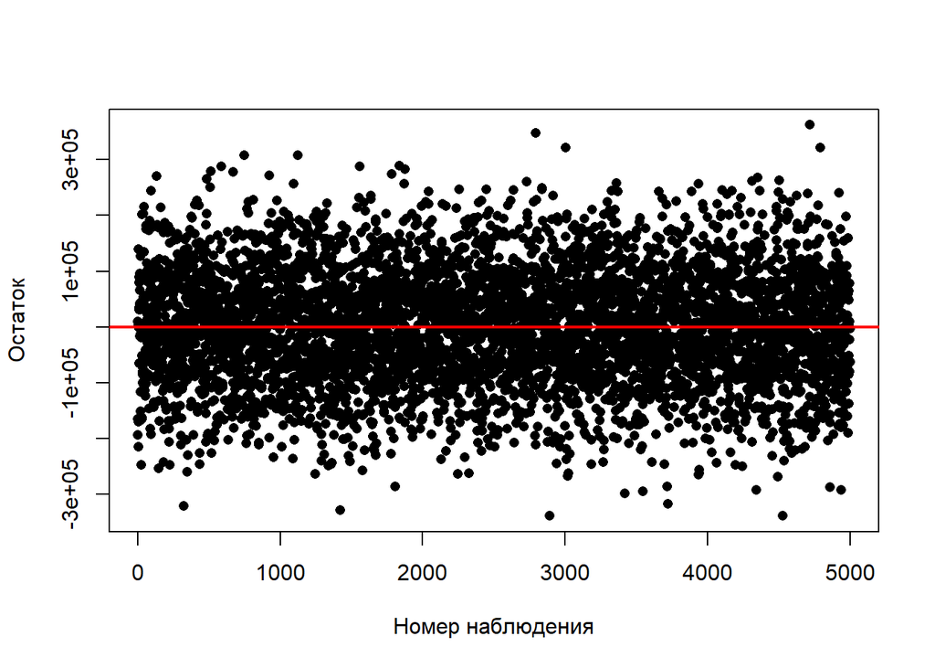

```r
res <- lm2$residuals
dfres <- data.frame(cbind(res, freq(res)[,2]))

plot(seq(1, nrow(new_df), 1), res, pch = 16, xlab = 'Номер наблюдения', ylab = 'Остаток')
abline(h = mean(res), col = 'red', lwd = 2)
```

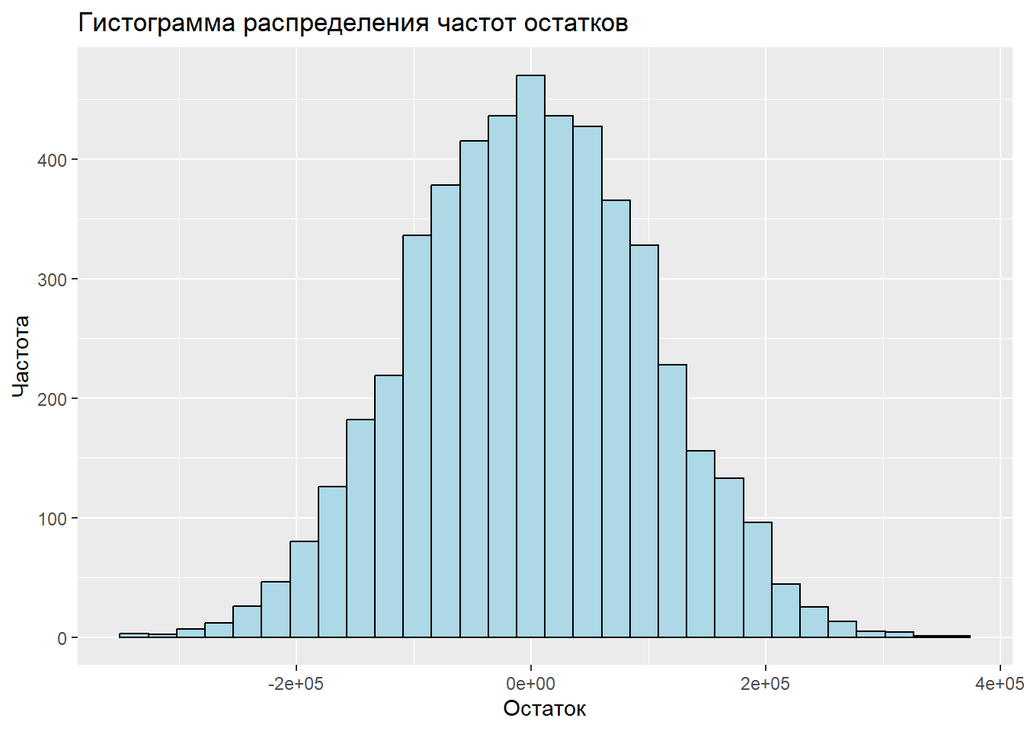

```r
ggplot(dfres, aes(x = res)) +
  geom_histogram(color = "black", fill = "lightblue") +
  ylab("Частота") +
  xlab("Остаток") +
  ggtitle('Гистограмма распределения частот остатков')
```

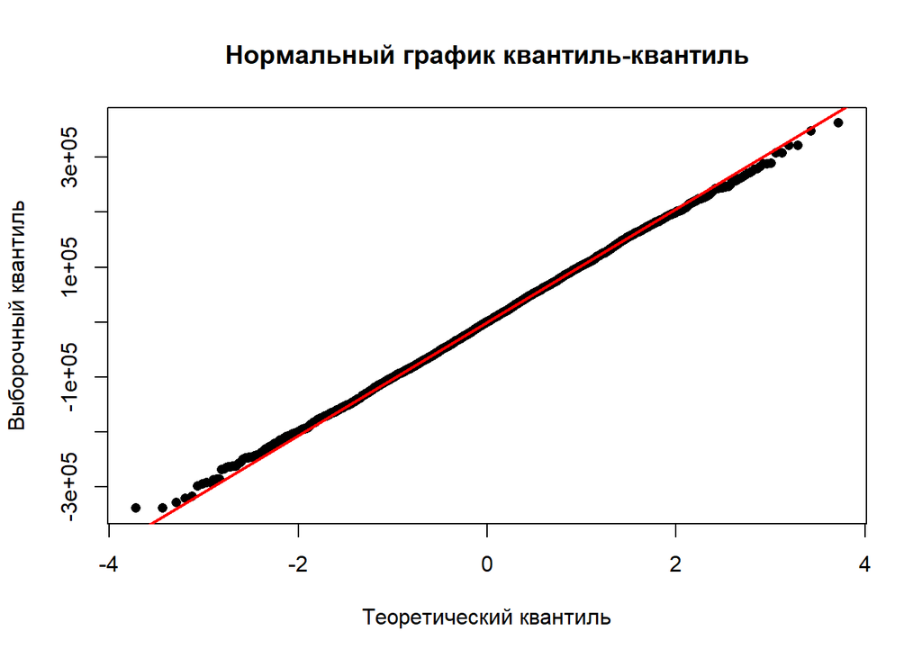

```r
qqnorm(res, pch = 16, xlab = 'Теоретический квантиль', ylab = 'Выборочный квантиль',
       main = 'Нормальный график квантиль-квантиль')
qqline(res, col = 'red', lwd = 2)
```

Теперь проверим их остатки на нормальность

```r
pander(shapiro.test(res))
```

Shapiro-Wilk normality test: `res`

| Test statistic | P value |
| --- | --- |
| 0.9996 | 0.341 |

```r
pander(jarque.bera.test(res))
```

Jarque Bera Test: `res`

| Test statistic | df | P value |
| --- | --- | --- |
| 4.742 | 2 | 0.09337 |

На основе полученных результатов можно сделать вывод о том, что нулевая гипотеза о нормальности распределения не отвергается.

### Построение графика наблюдаемых и модельных значений зависимой переменной

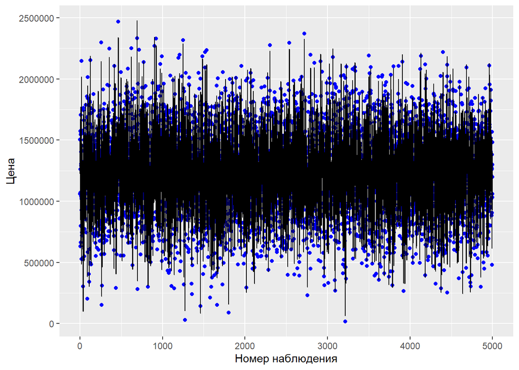

```r
pred <- predict(lm2)
ggplot(new_df, aes(x = seq(1, nrow(new_df), 1), y = Price)) +
  geom_point(color = "blue") +
  geom_line(aes(x = seq(1, nrow(new_df), 1), y = pred)) +
  labs(x = "Номер наблюдения", y = "Цена")
```

```r
summary(lm2)
```

```
##
## Call:
## lm(formula = Price ~ Avg..Area.Income + Avg..Area.House.Age +
##     Avg..Area.Number.of.Rooms + Area.Population, data = new_df)
##
## Residuals:
##     Min      1Q  Median      3Q     Max
## -338419  -70058     132   69074  362025
##
## Coefficients:
##                             Estimate Std. Error t value Pr(>|t|)
## (Intercept)               -2.638e+06  1.716e+04 -153.73   <2e-16 ***
## Avg..Area.Income           2.158e+01  1.343e-01  160.74   <2e-16 ***
## Avg..Area.House.Age        1.657e+05  1.443e+03  114.77   <2e-16 ***
## Avg..Area.Number.of.Rooms  1.216e+05  1.423e+03   85.48   <2e-16 ***
## Area.Population            1.520e+01  1.442e-01  105.39   <2e-16 ***
## ---
## Signif. codes:  0 '***' 0.001 '**' 0.01 '*' 0.05 '.' 0.1 ' ' 1
##
## Residual standard error: 101200 on 4995 degrees of freedom
## Multiple R-squared:  0.918,  Adjusted R-squared:  0.9179
## F-statistic: 1.398e+04 on 4 and 4995 DF,  p-value: < 2.2e-16
```

```r
pander(summary(lm2))
```

|  | Estimate | Std. Error | t value | Pr(>\|t\|) |
| --- | --- | --- | --- | --- |
| **(Intercept)** | -2637561 | 17158 | -153.7 | 0 |
| **Avg..Area.Income** | 21.58 | 0.1343 | 160.7 | 0 |
| **Avg..Area.House.Age** | 165658 | 1443 | 114.8 | 0 |
| **Avg..Area.Number.of.Rooms** | 121598 | 1423 | 85.48 | 0 |
| **Area.Population** | 15.2 | 0.1442 | 105.4 | 0 |

Fitting linear model: Price ~ Avg..Area.Income + Avg..Area.House.Age + Avg..Area.Number.of.Rooms + Area.Population

| Observations | Residual Std. Error | $R^2$ | Adjusted $R^2$ |
| --- | --- | --- | --- |
| 5000 | 101159 | 0.918 | 0.9179 |

Теперь посчитаем коэффициенты эластичности

```r
for (i in 1:4){
  if (i== 4) k=i+1 else k=i
print(lm2$coefficients[i+1]*mean(new_df[[k]])/mean(new_df$Price))
}
```

```
## Avg..Area.Income
##           1.2014
## Avg..Area.House.Age
##           0.8036652
## Avg..Area.Number.of.Rooms
##                 0.6896531
## Area.Population
##        0.446033
```

Корректная запись уравнения будет выглядеть так

$y = -2637561 + 21.58*x_1 + 165658*x_2 + 121598*x_3 + 15,2*x_4 + \epsilon$

Коэффициент регрессии b1 показывает, на какую величину в среднем изменится результативный признак Y, если переменная Xj увеличится на едицину своего измерения, следовательно исходя из наших результатов Цена будет равена -2637561, если обе независимые переменные будут равные 0 и соотвественно изменится на величины 21.58, 165658, 121598, 15.2 при изменении данных независимых перемнных на единицу.

Самой влияющей переменной оказалось `Avg..Area.Income`, поскольку при увеличении переменной на 1%, `Price` вырастет в среднем приблизительно на 1.2%. Меньше всего влияние оказывает `Area.Population`, поскольку при увеличении переменной на 1%, `Price` вырастет в среднем приблизительно на 0.45%.

Как можно видеть, значения коэффициентов эластичности отличаются не очень сильно.

# Проведём нелинейный (степенной) анализ

Посмотрим на графики рассеяния.

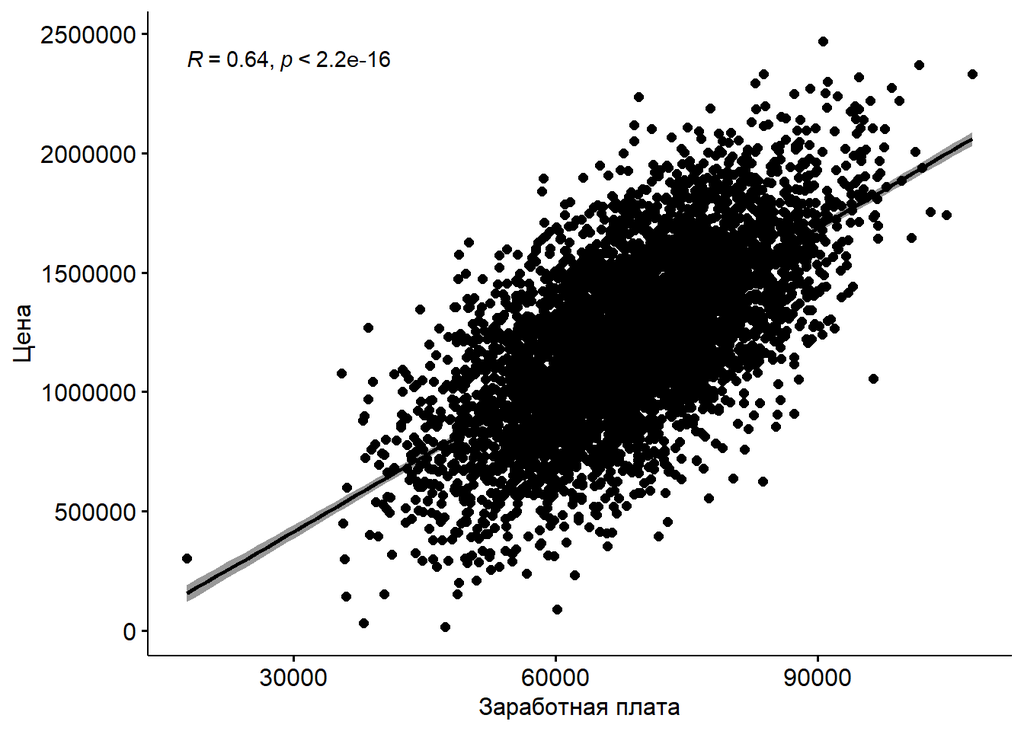

```r
ggscatter(new_df, x = "Avg..Area.Income", y = "Price",
          add = "reg.line", conf.int = TRUE,
          cor.coef = TRUE, cor.method = "pearson",
          xlab = "Заработная плата", ylab = "Цена")
```

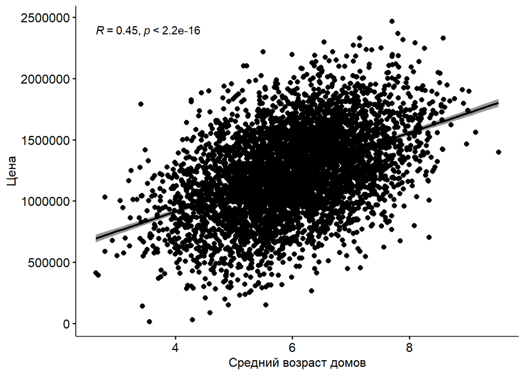

```r
ggscatter(new_df, x = "Avg..Area.House.Age", y = "Price",
          add = "reg.line", conf.int = TRUE,
          cor.coef = TRUE, cor.method = "pearson",
          xlab = "Средний возраст домов", ylab = "Цена")
```

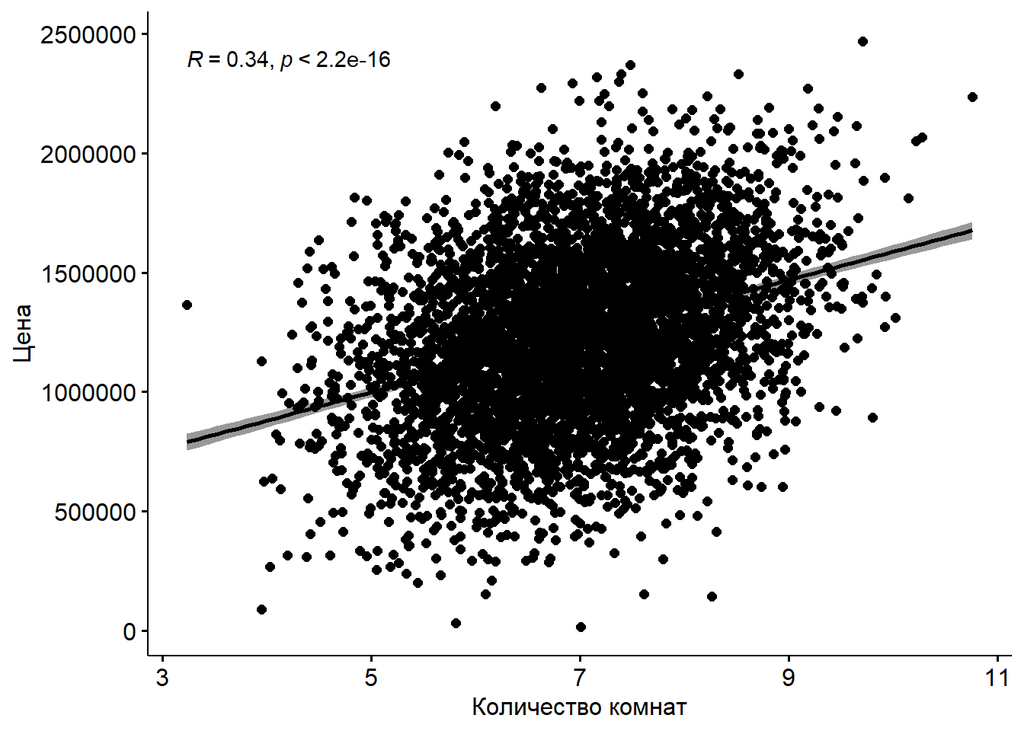

```r
ggscatter(new_df, x = "Avg..Area.Number.of.Rooms", y = "Price",
          add = "reg.line", conf.int = TRUE,
          cor.coef = TRUE, cor.method = "pearson",
          xlab = "Количество комнат", ylab = "Цена")
```

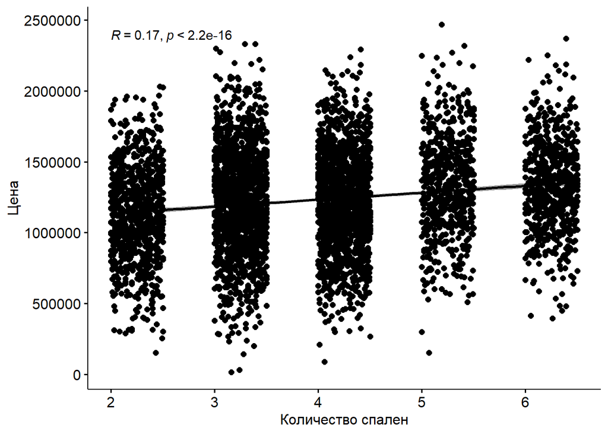

```r
ggscatter(new_df, x = "Avg..Area.Number.of.Bedrooms", y = "Price",
          add = "reg.line", conf.int = TRUE,
          cor.coef = TRUE, cor.method = "pearson",
          xlab = "Количество спален", ylab = "Цена")
```

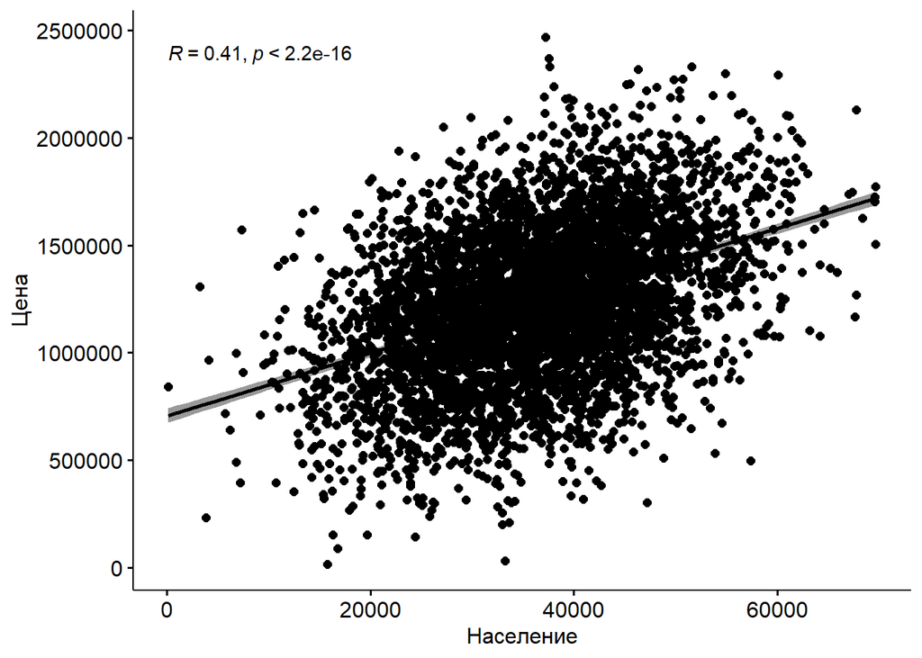

```r
ggscatter(new_df, x = "Area.Population", y = "Price",
          add = "reg.line", conf.int = TRUE,
          cor.coef = TRUE, cor.method = "pearson",
          xlab = "Население", ylab = "Цена")
```

Как можно видеть по графику, достаточно сложно предположить возможную зависимость между ценой квартиры и другими параметрами. Попробуем построить экспоненциальную модель.

```r
new_df$logP <- log(new_df$Price)

nlm <- lm(logP ~ Avg..Area.Income + Avg..Area.House.Age + Avg..Area.Number.of.Rooms + Avg..Area.Number.of.Bedrooms+Area.Population, new_df)
summary(nlm)
```

```
##
## Call:
## lm(formula = logP ~ Avg..Area.Income + Avg..Area.House.Age +
##     Avg..Area.Number.of.Rooms + Avg..Area.Number.of.Bedrooms +
##     Area.Population, data = new_df)
##
## Residuals:
##     Min      1Q  Median      3Q     Max
## -3.2369 -0.0603  0.0107  0.0788  0.3759
##
## Coefficients:
##                               Estimate Std. Error t value Pr(>|t|)
## (Intercept)                  1.046e+01  2.332e-02 448.548   <2e-16 ***
## Avg..Area.Income             1.957e-05  1.826e-07 107.219   <2e-16 ***
## Avg..Area.House.Age          1.512e-01  1.962e-03  77.057   <2e-16 ***
## Avg..Area.Number.of.Rooms    1.092e-01  2.182e-03  50.037   <2e-16 ***
## Avg..Area.Number.of.Bedrooms 2.319e-03  1.779e-03   1.304    0.192
## Area.Population              1.375e-05  1.960e-07  70.144   <2e-16 ***
## ---
## Signif. codes:  0 '***' 0.001 '**' 0.01 '*' 0.05 '.' 0.1 ' ' 1
##
## Residual standard error: 0.1375 on 4994 degrees of freedom
## Multiple R-squared:  0.8333, Adjusted R-squared:  0.8332
## F-statistic:  4993 on 5 and 4994 DF,  p-value: < 2.2e-16
```

Как видим, коэффициент регрессии у среднего количества спален оказался незначимым, поэтому удалим его. (Либо его, либо среднее количество комнат нужно было убирать из модели, поскольку они коррелируемы)

```r
nlm1 <- lm(logP ~ Avg..Area.Income + Avg..Area.House.Age + Avg..Area.Number.of.Rooms + Area.Population, new_df)
summary(nlm)
```

```
##
## Call:
## lm(formula = logP ~ Avg..Area.Income + Avg..Area.House.Age +
##     Avg..Area.Number.of.Rooms + Avg..Area.Number.of.Bedrooms +
##     Area.Population, data = new_df)
##
## Residuals:
##     Min      1Q  Median      3Q     Max
## -3.2369 -0.0603  0.0107  0.0788  0.3759
##
## Coefficients:
##                               Estimate Std. Error t value Pr(>|t|)
## (Intercept)                  1.046e+01  2.332e-02 448.548   <2e-16 ***
## Avg..Area.Income             1.957e-05  1.826e-07 107.219   <2e-16 ***
## Avg..Area.House.Age          1.512e-01  1.962e-03  77.057   <2e-16 ***
## Avg..Area.Number.of.Rooms    1.092e-01  2.182e-03  50.037   <2e-16 ***
## Avg..Area.Number.of.Bedrooms 2.319e-03  1.779e-03   1.304    0.192
## Area.Population              1.375e-05  1.960e-07  70.144   <2e-16 ***
## ---
## Signif. codes:  0 '***' 0.001 '**' 0.01 '*' 0.05 '.' 0.1 ' ' 1
##
## Residual standard error: 0.1375 on 4994 degrees of freedom
## Multiple R-squared:  0.8333, Adjusted R-squared:  0.8332
## F-statistic:  4993 on 5 and 4994 DF,  p-value: < 2.2e-16
```

```r
pander(summary(nlm1))
```

|  | Estimate | Std. Error | t value | Pr(>\|t\|) |
| --- | --- | --- | --- | --- |
| **(Intercept)** | 10.46 | 0.02332 | 448.5 | 0 |
| **Avg..Area.Income** | 1.958e-05 | 1.825e-07 | 107.3 | 0 |
| **Avg..Area.House.Age** | 0.1512 | 0.001962 | 77.07 | 0 |
| **Avg..Area.Number.of.Rooms** | 0.1105 | 0.001934 | 57.14 | 0 |
| **Area.Population** | 1.374e-05 | 1.96e-07 | 70.13 | 0 |

Fitting linear model: logP ~ Avg..Area.Income + Avg..Area.House.Age + Avg..Area.Number.of.Rooms + Area.Population

| Observations | Residual Std. Error | $R^2$ | Adjusted $R^2$ |
| --- | --- | --- | --- |
| 5000 | 0.1375 | 0.8333 | 0.8331 |

Значение $R^2_{adj.}$ достаточно высокое и составляет 0,8331. Общая формула: $y =e^{\beta_0+\beta_1*x_1+\beta_2*x_2+\beta_3*x_3+\beta_4*x_4}$, где $\beta_0$ константа `Intercept`, а $\beta_i$ коэффициент перед соответствующей переменной $x_i$ (Avg..Area.Income, Avg..Area.House.Age и т.д.). Соответственно, при увелечении переменной $\x_i$ на 1, значение `y` вырастет в $e^{\beta_i}$ раз.

Построим графики остатков модели.

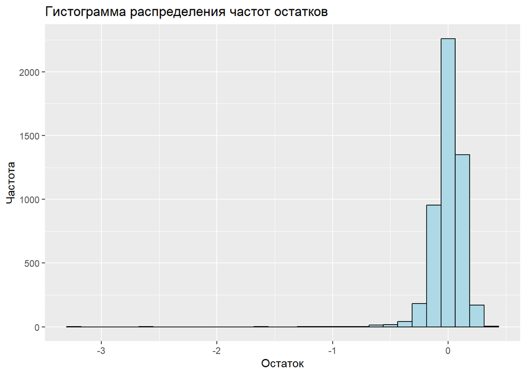

```r
res <- nlm1$residuals
dfres <- data.frame(cbind(res, freq(res)[,2]))
ggplot(dfres, aes(x = res)) +
  geom_histogram(color = "black", fill = "lightblue") +
  ylab("Частота") +
  xlab("Остаток") +
  ggtitle('Гистограмма распределения частот остатков')
```

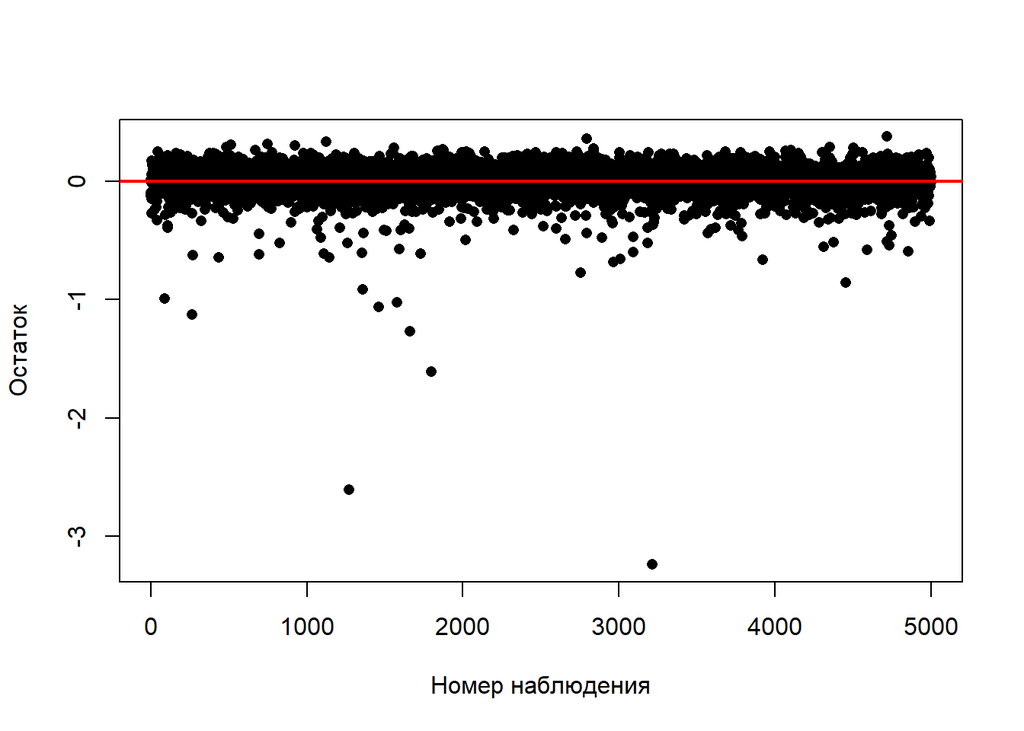

```r
plot(seq(1, nrow(new_df), 1), res, pch = 16, xlab = 'Номер наблюдения', ylab = 'Остаток')
abline(h = mean(res), col = 'red', lwd = 2)
```

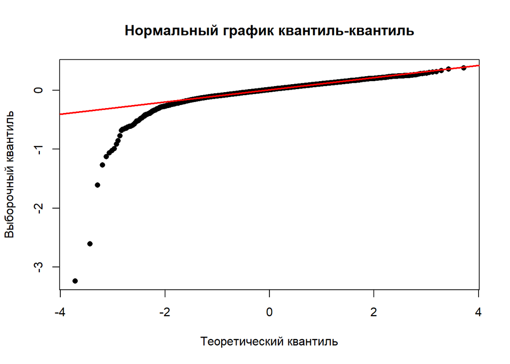

```r
qqnorm(res, pch = 16, xlab = 'Теоретический квантиль', ylab = 'Выборочный квантиль',
       main = 'Нормальный график квантиль-квантиль')
qqline(res, col = 'red', lwd = 2)
```

Можем видеть большое количество наблюдений остатков, которые сильно выделяются. Проверим нормальность распределения остатков.

```r
pander(shapiro.test(res))
```

Shapiro-Wilk normality test: `res`

| Test statistic | P value |
| --- | --- |
| 0.7746 | 7.206e-64 * * * |

```r
pander(jarque.bera.test(res))
```

Jarque Bera Test: `res`

| Test statistic | df | P value |
| --- | --- | --- |
| 1962933 | 2 | 0 * * * |

Следовательно, гипотеза и нормальности распределения остатков отвергается. Построение графикф модельных и фактических значений (предсказанных и истинных) не имеет смысла из-за того, что на нем ничего не будет видно.

Проведем тест Бреуша-Пагана.

```r
bptest(nlm1)
```

```
##
##  studentized Breusch-Pagan test
##
## data:  nlm1
## BP = 91.996, df = 4, p-value < 2.2e-16
```

Статистика теста составляет 91.996 , а соответствующее значение p-value меньше 0,05, мы можем отвергнуть нулевую гипотезу. Значит в регрессионной модели присутствует гетероскедастичность.